# Latrine Results for November DayCent paper

T Stephenson

2023-08-24

## Pre-processing of Microbial Data

Here are the highlights:

For 16S: only forward reads were used, as reverse reads were low quality. Reads were filtered (filterAndTrim()) with maxEE = 10 and no truncation. Filtered reads were dereplicated (derepFastq()), the core sample inference algorithm was applied (dada()), and chimeras were removed (removeBimeraDenovo()). This resulted in an acceptable amount of data making it through the processing steps: the lowest sample had 3481 reads. A DNAStringSet was created from the ASVs, and taxonomy was assigned using the “SILVA_SSU_r138_2019” training set and IdTaxa() function in the DECIPHER package. The resulting sequence table and taxa ID matrix were saved: this is the processed data loaded into this script for visualization/plotting.

For ITS: Primers were identified and removed using ‘cutadapt.’ The reads were filtered in the same way as 16S reads: only forward reads were used, as reverse reads were low quality. Reads were filtered (filterAndTrim()) with maxEE = 10 and no truncation. Filtered reads were dereplicated (derepFastq()), the core sample inference algorithm was applied (dada()), and chimeras were removed (removeBimeraDenovo()). This resulted in an acceptable amount of data making it through the processing steps. A DNAStringSet was created from the ASVs, and taxonomy was assigned using the “UNITE_v2021_May2021” training set and IdTaxa() function in the DECIPHER package. The resulting sequence table and taxa ID matrix were saved: this is the processed data loaded into this script for visualization/plotting.

For both 16S and ITS, from the full datasets, only latrine (and paired control) treatments from Takone, Arthur River, and Goulds Country were extracted. Additionally, only samples from the “time final” sampling (after treatment was applied) were used. This resulted in 36 unique samples–12 from each site. For 16S data, 1 replicate from Arthur River (L6 and LC6) was removed due to very low read counts. None were removed from ITS data. Data further were filtered by removing any ASVs that classified as non-target groups. For 16S, eukaryotes or ASVs that did not classify at the domain level (“NA”) were removed. For ITS, ASVs that classified as rhizaria or eukaryotes of uncertain origin, or that did not classify at the kingdom level were removed.

Samples were rarefied to the lowest observation to calculate diversity indices.

## 16S

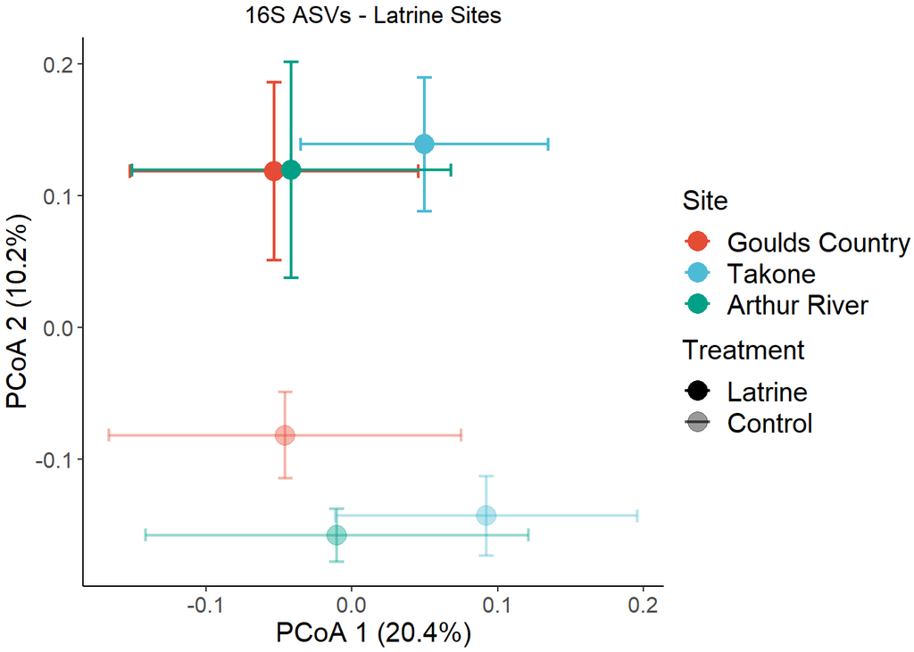

```r
ord_2
```

Latrine sites are clearly different from their paired controls! I really like this figure, though it doesn’t really have any statistical power–it just illustrates a point nicely.

### 16S Bar plots: Phyla

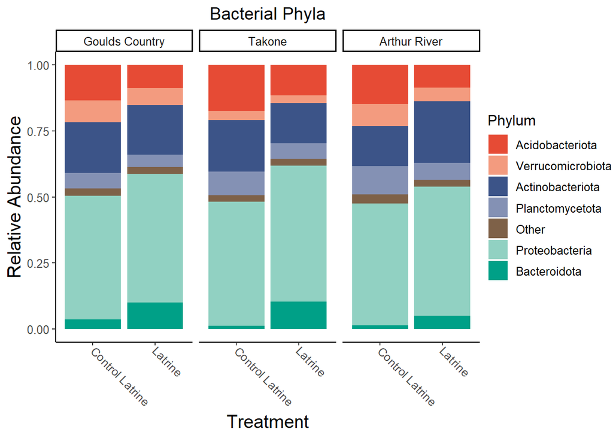

```r
bac_bar2
```

There are definitely differences between control and treatment sites. Specifically, the relative abundance of Acidobacteriota and Planctomycetota decreased at latrine sites; relative abundance of Proteobacteria and Bacteroidota (r-selected phyla) increased at latrine sites.

Overall, looks like a similar pattern to carcasses: r-selected increase w/trt (Proteo, Bac) and K-selected decrease (Acido). There was a significant main effect of latrine treatment for 4 of 7 phyla; a significant main effect of site was observed for 2 of 7. This figure could be cleaned up to show only differentially abundant phyla, dropping Verrucomicrobiota, Actinobacteriota, and “Other.” I’ll share this figure once I make it.

| Phylum | Model | Trt | Site | Trt:site | Notes |
| --- | --- | --- | --- | --- | --- |
| Acidobacteriota | lm | p<0.05, f1, 28 = 6.72 | X | x | LC > L |
| Verrucomicrobiota | lm | X | X | X | no sig effects |
| Actinobacteriota | glm, gamma | X | X | X | No sig effects |
| Planctomycetota | lm | p<0.01, F1,28 = 9.23 | p<0.05, F1,28 = 4.25 | X | L<LC, G<A. for site*trt, A is only site where L<LC |
| Other | Glm, gamma | X | X | X | nothing significant |
| Proteobacteria | lm | p<0.05, F1,28 = 4.59 | X | X | L>LC |
| Bacteroidota | lm | p<0.001, F1,28 = 36.76 | p<0.05, F1,28 = 4.04 | X | L>LC, G>A. for site*trt, L>LC at G, T only |

## ITS

*Note: for ITS, no samples were removed prior to rarefaction due to low read counts.*

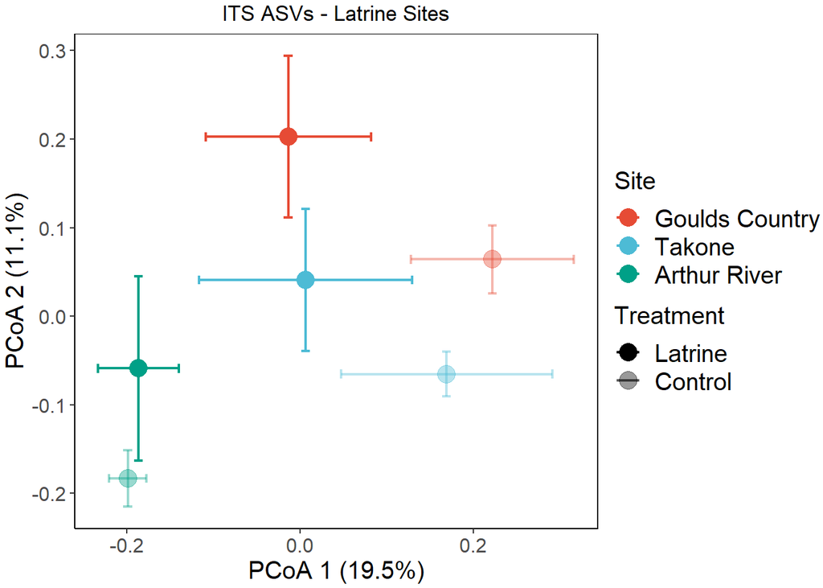

```r
funord
```

The clustering between latrine and control looks different but clear patterns do not emerge. Site appears to have at least as much influence as latrine treatment on fungal community composition.

## ITS Bar plots: Classes

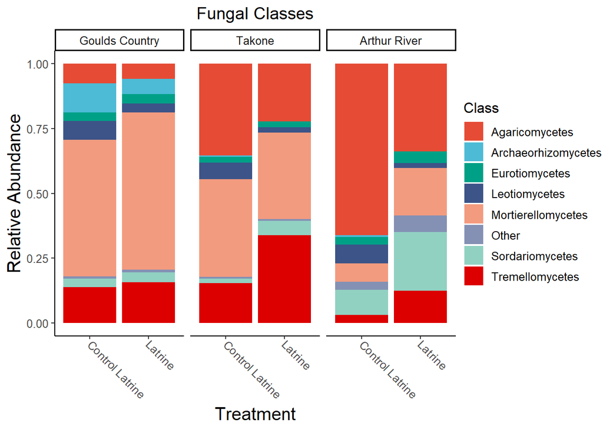

```r
fun_bar2
```

First observation is that sites are very different from one another–site differences may be greater than treatment differences. Classes that seem to be affected by treatment are: Agaricomycetes (decrease with treatment), maybe Mortierellomycetes (increase with treatment), Tremellomycetes (increase with treatment), and Sordariomycetes at Arthur River (increase with treatment).

The only class that was significantly affected by treatment is Leotiomycetes (see table below), which were lower at latrine sites vs. controls. Plotting only differentially abundant classes for fungi is therefore not feasible. Site-based variability was greater than treatment variability overall, with significant differences between sites observed for 5 of 8 classes. Likely, the period of ~30 days that elapsed between initial and final sampling was not long enough to change the fungal community, which is known to respond more slowly to changes than the bacterial community.

| Class | Model | Trt | Site | Trt:site | Notes | Etc |
| --- | --- | --- | --- | --- | --- | --- |
| Agaricomycetes | Glm, gamma | X | p<0.001, Chisq = 37.21 | X | G<A and G<T | Parasitic, pathogenic, symbiotic, or saprotrophic |
| Archaeorhizomycetes | lm, but not normal | X | X | X | Lots of observations are 0. | Only 1 observed order, family, genus |
| Eurotiomycetes | Glm, gamma | X | p<0.05, Chisq 7.42 | X | A higher than other sites, but no pairwise comparison is sig alone | Over 3800 species |
| Leotiomycetes | Glm, gamma | p<0.01, Chisq 8.52 | X | X | LC>L. only pairwise sig is Arthur LC>L | Many pathogens causing plant disease, powdery mildews |
| Mortierellomycetes | Glm, gamma | X | X | X | Closest to sig is A>G, T. site almost sig | ? |
| Other | Glm, gamma | X | p<0.0001, Chisq 61.05 | x | One observation removed b/c = 0 (GL2). A>G,T |  |
| Sordariomycetes | Glm, gamma | X | p<0.0001, Chisq 22.7 | X | A>G,T | Named for latin “sordes” (filth”) b/c some grow in feces. generally higher at L than LC, but not sig (and not at G, LC=L) |
| Tremellomycetes | Glm, gamma | X | p<0.05, Chisq 6.58 | X | no pairwise sites sig. L>LC at A is ALMOST sig | include yeasts, dimorphic taxa, and spp that form complex fruiting bodies |

## Soil Properties

Measured soil variables for latrine sites and the method used to obtain them are:

1. NO3 (ug/g dry soil) – 0.05M K2SO4 extraction, then colorimetric microplate assay
2. NH4 (ug/g dry soil) – 0.05M K2SO4 extraction, then colorimetric microplate assay
3. PO4 (ug/g dry soil) – 0.05M K2SO4 extraction, then colorimetric microplate assay
4. Dissolved C (ug/g dry soil) – 0.05M K2SO4 extraction, then Shimadzu
5. Totan N (ug/g dry soil) – 0.05M K2SO4 extraction, then Shimadzu
6. Electrical Conductivity (only for time final) – Jenway 3540 pH/Conductivity meter
7. pH (only for time final) – Jenway 3540 pH/Conductivity meter

What has already been done:

- Latrine sites isolated from carcass treatments, Bruny Island and time 0 removed.
- Outliers identified: For treatment sites, high outliers are possible; for control sites they are unlikely. To identify outliers/influential points, Cooks Distance test was used. Data were split by treatment, then observations with a Cooks Distance greater than 2 * the group mean of Cooks Distance were flagged. For control sites, these observations were replaced with the group mean for the appropriate site/treatment. Treatment values were retained as-is. This process was carried out for each response variable independently.

For some responses, I’ve plotted the log ratio ($log(treatment)/log(control)$) to allow visualization comparing the control and treatment sites. Log ratios >1 represent a change in the treatment greater than the change in the control. For most responses, I’ve chosen just to plot the absolute value of the response variable–the patterns are just as easy to visualize, and are further contextualized (i.e., you can see how low soil nitrate is compared to ammonium, etc).

## 1. Soil Nutrients

## 1a. Nitrate

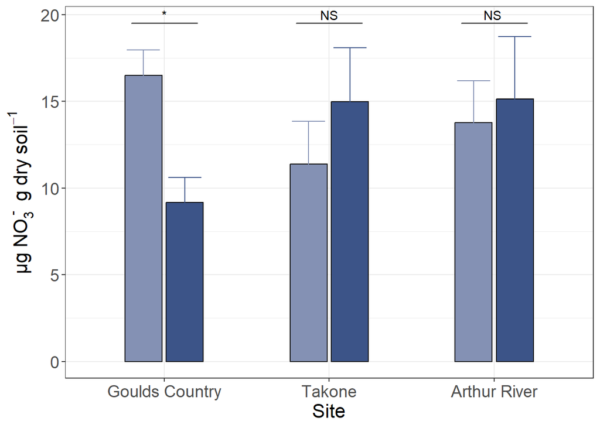

## 1b. Ammonium

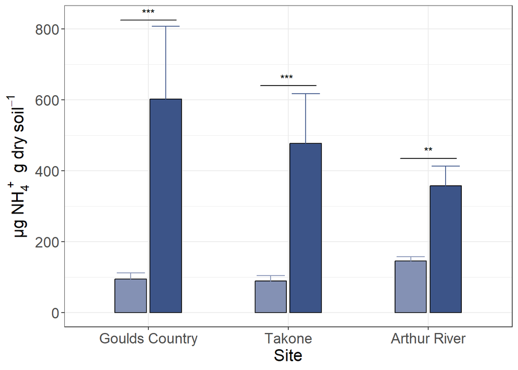

Ammonium was significantly higher at all latrine sites compared to control. The magnitude of the increase was greatest at Goulds Country (541%) and lowest at Arthur River (146%), which could be related to a precipitation gradient?

## 1c. Phosphate

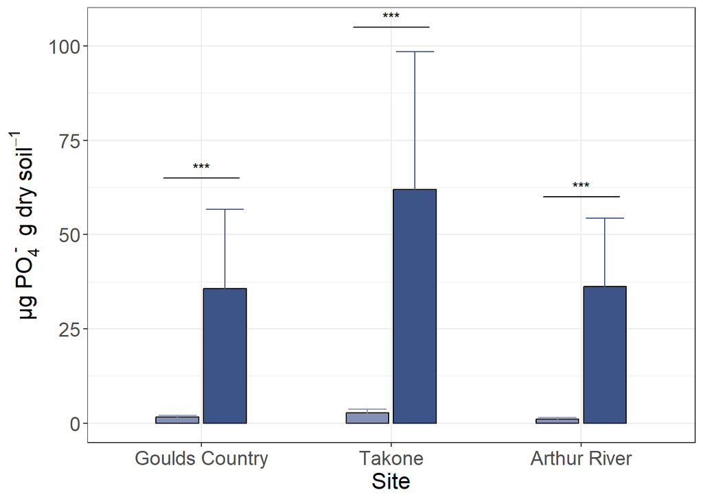

Devil scat significantly increased soil phosphate at all sites by an average of 2,573%.

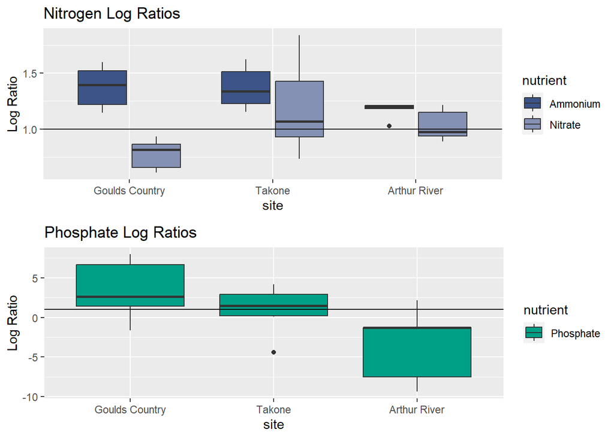

From the top panel, the lack of significant consistent effects for nitrate is apparent. Ammonium increases for all sites; it increases least at Arthur River. Could this be linked to precipitation? Lower precip could = lower NH4 if nitrification is not inhibited by wet soils. Link to precip data to investigate further.

## 2. TOC/TDN

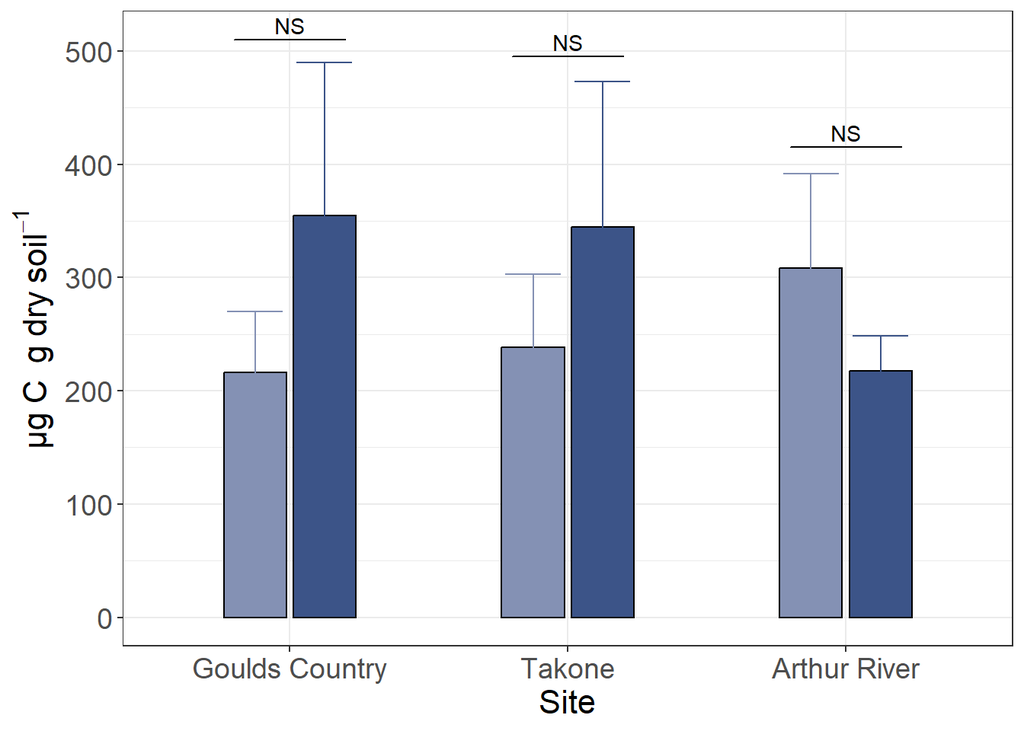

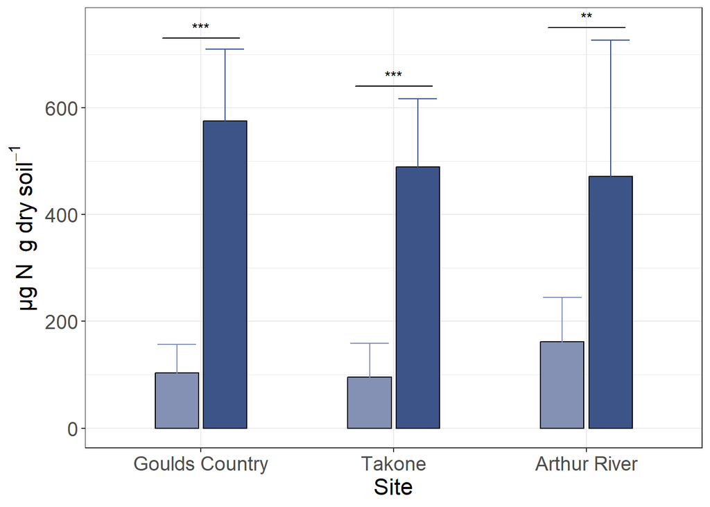

When all points are included, DOC is higher at latrine than control sites, though these differences were not significant. When a large outlier at Arthur River (L2) is excluded (this is the figure shown), latrine DOC is actually lower than control DOC for this site.

TDN is significantly higher (192 to 457%) at latrine vs control for all sites.

## soil pH/EC, moisture

#### Soil pH

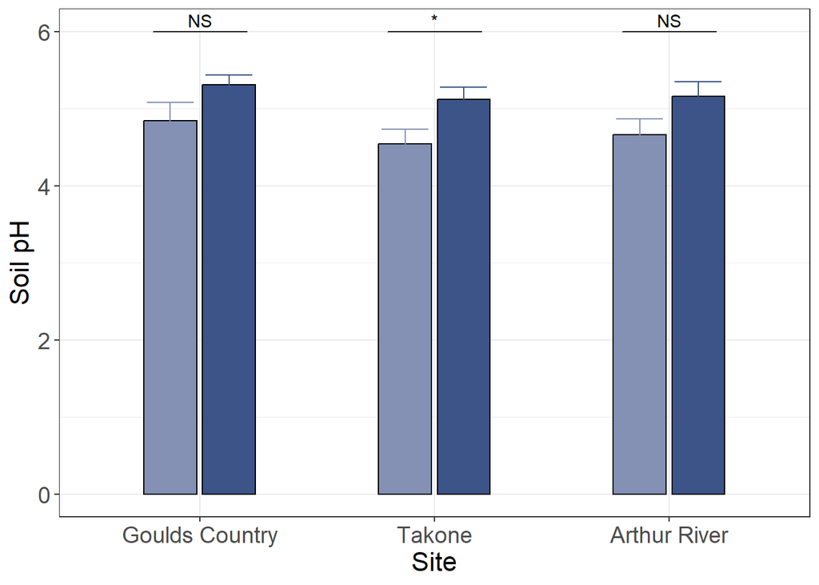

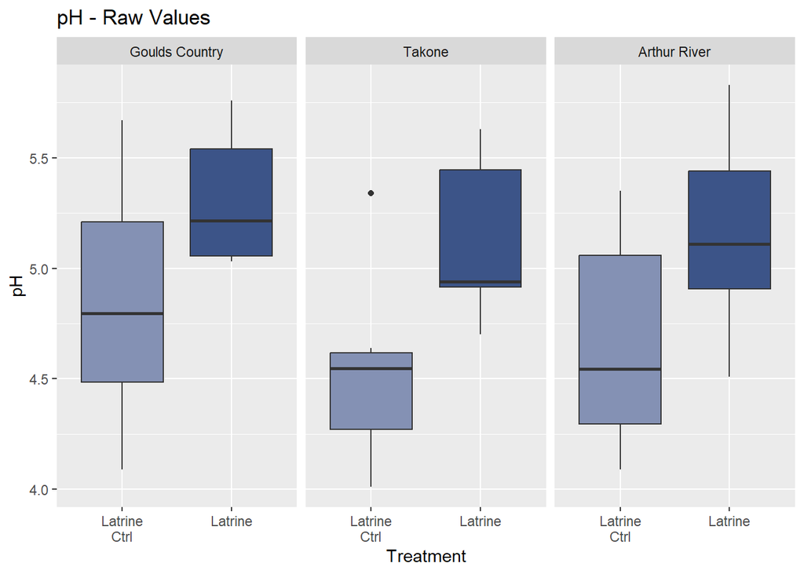

pH: these figures illustrate the effect of treatment as well as the trend of decreasing baseline/control pH from east to west across the island. At all sites, latrine treatments increase soil pH, though the difference was only significant at Takone. Probably this will be SI, not a main figure, but I prefer the boxplot to the bar plot here.

#### Soil EC

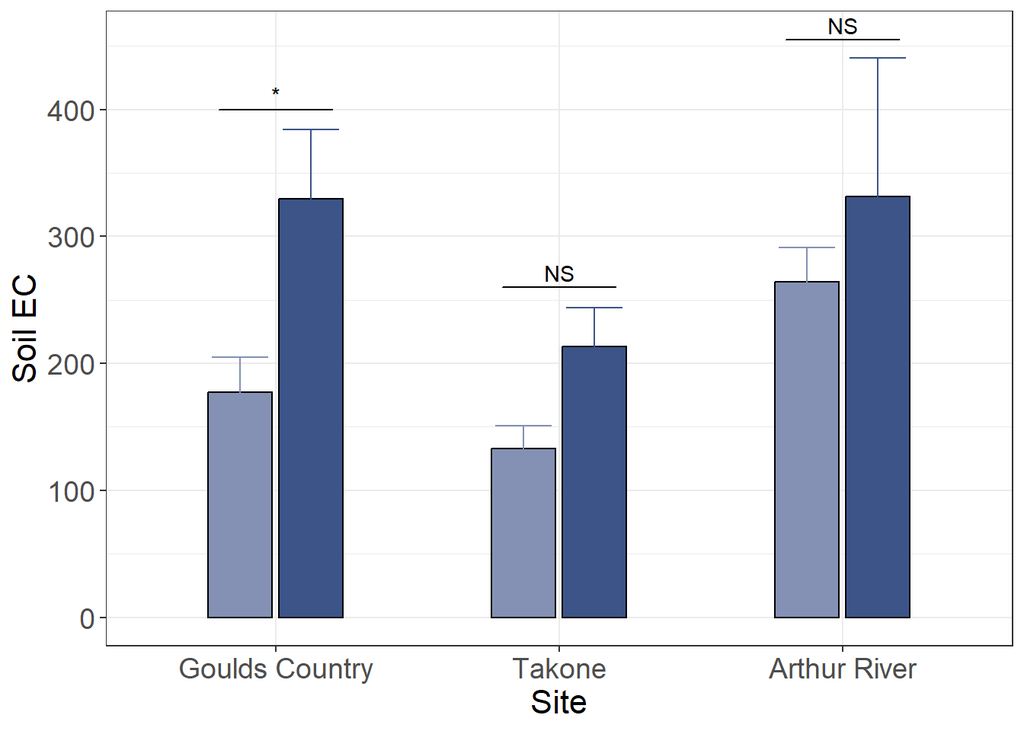

Similar to pH, latrine sites had higher EC than their controls for all sites; this difference was only significant at Goulds Country.